# BostonHousePricePrediction_PF

**Regression Project: Boston House Price Prediction**

**Objective**

The problem at hand is to predict the housing prices of a town or a suburb based on the features of the locality provided to us. In the process, we will identify the most important features affecting the price of the house and employ techniques of data preprocessing and build a linear regression model that predicts the prices for the unseen data.

```python
# Import libraries for data manipulation
import pandas as pd

import numpy as np

# Import libraries for data visualization
import matplotlib.pyplot as plt

import seaborn as sns

from statsmodels.graphics.gofplots import ProbPlot

# Import libraries for building linear regression model
from statsmodels.formula.api import ols

import statsmodels.api as sm

from sklearn.linear_model import LinearRegression

# Import library for preparing data
from sklearn.model_selection import train_test_split

# Import library for data preprocessing
from sklearn.preprocessing import MinMaxScaler

import warnings
warnings.filterwarnings("ignore")
```

```python
df = pd.read_csv("/Boston.csv")

df.head()
```

|  | CRIM | ZN | INDUS | CHAS | NOX | RM | AGE | DIS | RAD | TAX | PTRATIO | LSTAT | MEDV |
| --- | --- | --- | --- | --- | --- | --- | --- | --- | --- | --- | --- | --- | --- |
| 0 | 0.00632 | 18.0 | 2.31 | 0 | 0.538 | 6.575 | 65.2 | 4.0900 | 1 | 296 | 15.3 | 4.98 | 24.0 |
| 1 | 0.02731 | 0.0 | 7.07 | 0 | 0.469 | 6.421 | 78.9 | 4.9671 | 2 | 242 | 17.8 | 9.14 | 21.6 |
| 2 | 0.02729 | 0.0 | 7.07 | 0 | 0.469 | 7.185 | 61.1 | 4.9671 | 2 | 242 | 17.8 | 4.03 | 34.7 |
| 3 | 0.03237 | 0.0 | 2.18 | 0 | 0.458 | 6.998 | 45.8 | 6.0622 | 3 | 222 | 18.7 | 2.94 | 33.4 |
| 4 | 0.06905 | 0.0 | 2.18 | 0 | 0.458 | 7.147 | 54.2 | 6.0622 | 3 | 222 | 18.7 | 5.33 | 36.2 |

**Observation on the data load:**

1. The dataset is loaded successfully, showing the first 5 rows and all 13 columns.
2. The data is read correctly and ready for further exploration

```python
df.info()
```

```
<class 'pandas.core.frame.DataFrame'>
RangeIndex: 506 entries, 0 to 505
Data columns (total 13 columns):
 #   Column   Non-Null Count  Dtype
---  ------   --------------  -----
 0   CRIM     506 non-null    float64
 1   ZN       506 non-null    float64
 2   INDUS    506 non-null    float64
 3   CHAS     506 non-null    int64
 4   NOX      506 non-null    float64
 5   RM       506 non-null    float64
 6   AGE      506 non-null    float64
 7   DIS      506 non-null    float64
 8   RAD      506 non-null    int64
 9   TAX      506 non-null    int64
 10  PTRATIO  506 non-null    float64
 11  LSTAT    506 non-null    float64
 12  MEDV     506 non-null    float64
dtypes: float64(10), int64(3)
memory usage: 51.5 KB
```

**Observation:**

1. All the values in the table is numeric and there is no missing entries in the table.
2. The datatypes used in the table are Floats and Integers
3. There are 506 rows of non-null observations and 13 columns in the dataset

```python
#Check for duplicate entries in the data
df.duplicated().sum()
```

```
np.int64(0)
```

**Summary statistics of the dataset:**

```python
## print the statistical summary of the data
df.describe().T
```

|  | count | mean | std | min | 25% | 50% | 75% | max |
| --- | --- | --- | --- | --- | --- | --- | --- | --- |
| CRIM | 506.0 | 3.613524 | 8.601545 | 0.00632 | 0.082045 | 0.25651 | 3.677083 | 88.9762 |
| ZN | 506.0 | 11.363636 | 23.322453 | 0.00000 | 0.000000 | 0.00000 | 12.500000 | 100.0000 |
| INDUS | 506.0 | 11.136779 | 6.860353 | 0.46000 | 5.190000 | 9.69000 | 18.100000 | 27.7400 |
| CHAS | 506.0 | 0.069170 | 0.253994 | 0.00000 | 0.000000 | 0.00000 | 0.000000 | 1.0000 |
| NOX | 506.0 | 0.554695 | 0.115878 | 0.38500 | 0.449000 | 0.53800 | 0.624000 | 0.8710 |
| RM | 506.0 | 6.284634 | 0.702617 | 3.56100 | 5.885500 | 6.20850 | 6.623500 | 8.7800 |
| AGE | 506.0 | 68.574901 | 28.148861 | 2.90000 | 45.025000 | 77.50000 | 94.075000 | 100.0000 |
| DIS | 506.0 | 3.795043 | 2.105710 | 1.12960 | 2.100175 | 3.20745 | 5.188425 | 12.1265 |
| RAD | 506.0 | 9.549407 | 8.707259 | 1.00000 | 4.000000 | 5.00000 | 24.000000 | 24.0000 |
| TAX | 506.0 | 408.237154 | 168.537116 | 187.00000 | 279.000000 | 330.00000 | 666.000000 | 711.0000 |
| PTRATIO | 506.0 | 18.455534 | 2.164946 | 12.60000 | 17.400000 | 19.05000 | 20.200000 | 22.0000 |
| LSTAT | 506.0 | 12.653063 | 7.141062 | 1.73000 | 6.950000 | 11.36000 | 16.955000 | 37.9700 |
| MEDV | 506.0 | 22.532806 | 9.197104 | 5.00000 | 17.025000 | 21.20000 | 25.000000 | 50.0000 |

**Observation from this dataset:**

• All 13 columns have 506 non-null values, consistent with no missing data

• ZN: median 0 indicates that over half the towns have no land zoned for large residential lots and the mean (11.4) is pulled by a few high-value outliers that has lots over 25,000 square feet

• CHAS: a binary variable with a mean of (0.069) indicates that only about 7% of tracts border the Charles River.

• NOX: ranges from 0.385 to 0.871, values fairly evenly spread with mean and median closer to ~0.55, indicating the Nitric Oxide concentration is fairly evenly spread (parts per 10 million).

*However, this interpretation of data alone does not conclude that the pollution is much concentrated near industrial zone, which the later analysis reveals.*

• RM: mean and median are roughly close around ~6.2, suggesting symmetric distribution centered around 6 rooms per dwelling

• AGE: median (77.5) is much higher than the means suggests that most towns have a large proportion of owner-occupied units/homes built before 1940

• DIS: right skewed, with most values between 2.1 and 5.2, but a max of 12.1 indicating some towns are much farther from employment centers

• RAD: show a large jump between mean/median and the 75% and max, likely to suggest that a subset of towns closer to the highway share the same top accessibility, while the rest are spread across lower values representing less direct highway access

• TAX: shows a large jump between mean/median to 75th percentile and max, indicating that a meaningful share of towns has tax rates roughly double the typical rate, then the properties taxed at (296 per $10000)

• PTRATIO: Pupil-teacher ratio by town, seem to have a fairly tight distribution with mean and median close to each other (~19)

*Even though this data alone does not act as a significant indicator of home value, running a correlation matrix with other dataset reveals that every additional student per teacher ratio is associated with a ~4.9% drop in median home value, which later analysis reveals *

• LSTAT: right skewed, mean higher than median, and max of ~38, indicate some areas have a high percentage of lower status population

• MEDV: the value ranges from 5 to 50, with mean and median fairly close, indicating the mean/median value of the owner-occupied homes are in the ($22,000) range but the max value of 50 suggests the value of owner-occupied homes caps at (50,000)

```python
## Check for missing values in the data
df.isnull().sum()
```

|  | 0 |
| --- | --- |
| CRIM | 0 |
| ZN | 0 |
| INDUS | 0 |
| CHAS | 0 |
| NOX | 0 |
| RM | 0 |
| AGE | 0 |
| DIS | 0 |
| RAD | 0 |
| TAX | 0 |
| PTRATIO | 0 |
| LSTAT | 0 |
| MEDV | 0 |

**dtype:** int64

**Exploratory Data Analysis and Data Preprocessing**

**Univariate Analysis**

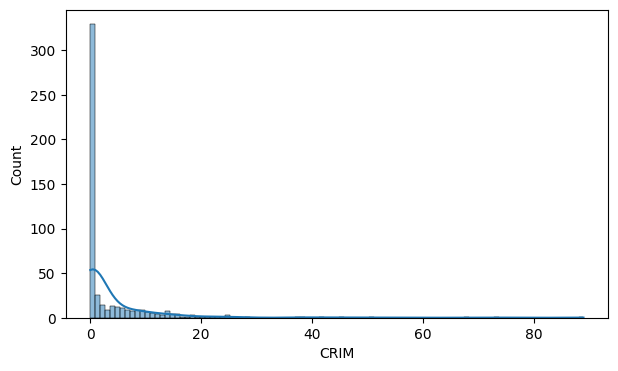

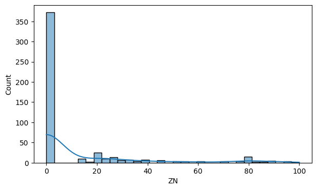

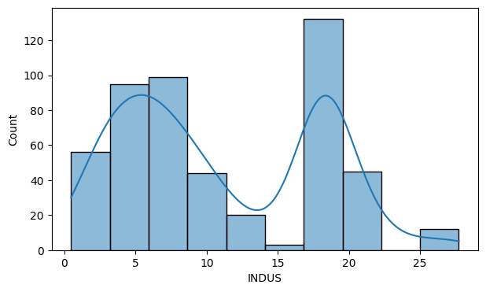

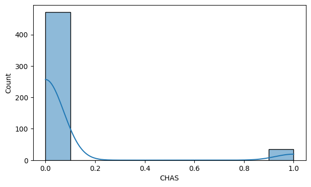

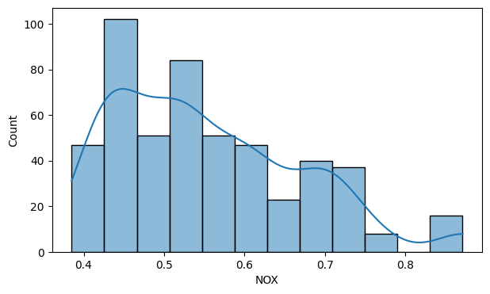

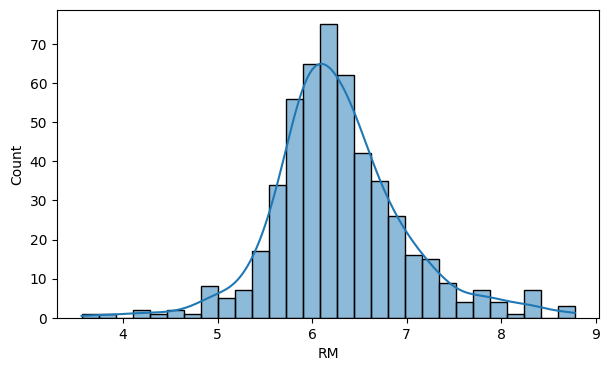

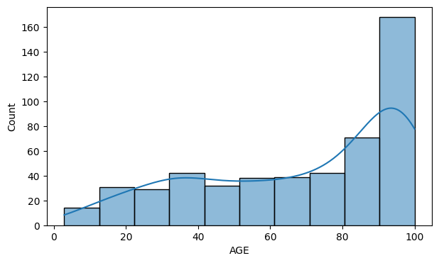

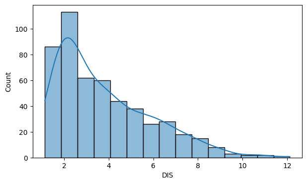

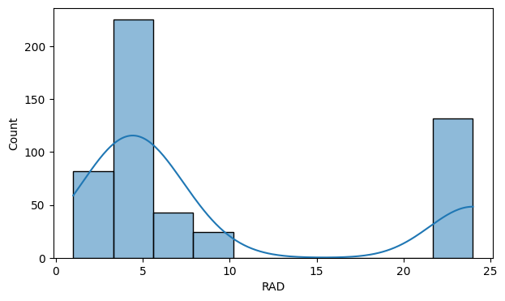

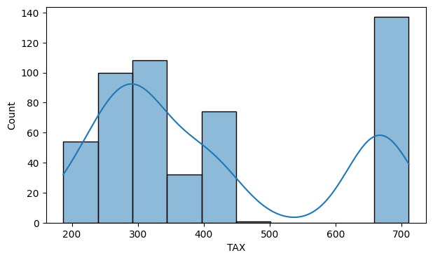

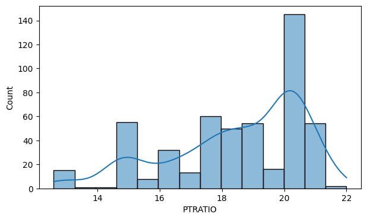

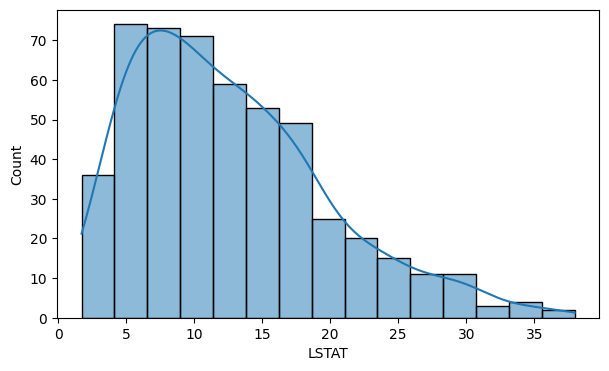

[1 more figures not shown]

```python
# Plotting all the columns to look at their distributions
for i in df.columns:

    plt.figure(figsize = (7, 4))
    sns.histplot(data = df, x = i, kde = True)
    plt.show()
```

**Observation on the graph:**

The graphs are consistent with the observation made from the data statistics

Right Skewed: CRIM, ZN, CHAS, DIS, LSTAT

Approximately Normal (Symmetric): RM, PTRATIO

Left-Skewed: AGE

Bimodal or Irregular: RAD, TAS, NOX, INDUS

Approximately Uniform with a Cap: MEDV

As the dependent variable is sightly skewed, we will apply a log transformation on the 'MEDV' column and check the distribution of the transformed column.

```python
df['MEDV_log'] = np.log(df['MEDV'])
```

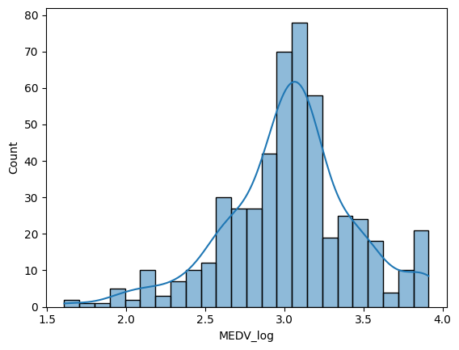

```python
sns.histplot(data = df, x = 'MEDV_log', kde = True)
```

**Observation:**

The log-transformed variable (MEDV_log) appears to have a nearly normal distribution without skew, and hence we can proceed.

**Bivariate Analysis**

Let's check the correlation using the heatmap

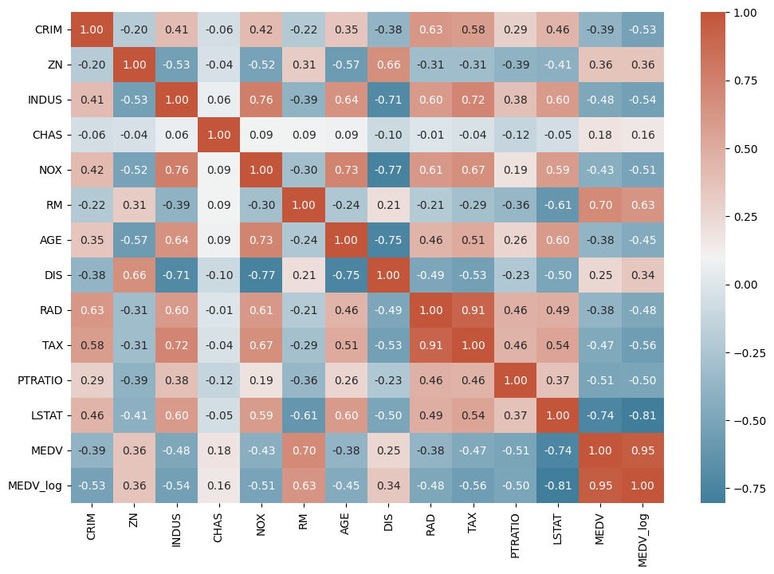

```python
 ####Seaborn function to Visualize correlation matrix as a color-coded grid
 ###df.corr computes pairwise correlation coefficients between numerical columns,
 ## producing the matrix that gets passed into the heatmap
plt.figure(figsize = (12, 8))
cmap = sns.diverging_palette(230, 20, as_cmap = True)
sns.heatmap(df.corr(), annot = True, fmt = '.2f', cmap = cmap)
plt.show()
```

**Observation:**

**Strong Positive Correlations (dark orange, >=0.70)**

• RAD & TAX: towns with better highway access tend to have much higher property taxes

• INDUS & NOX: more industrial towns have significantly higher pollution levels

• AGE & NOX: older housing stock is associated with higher pollution, likely because older towns are more industrialized

**Strong Negative Correlations:(dark blue, <=-0.70)**

• DIS & NOX: towns farther from employment centers have noticeably lower pollution

• DIS & AGE: towns farther from the city have newer homes

• DIS & INDUS: farther towns have less industrial activity

• LSTAT & MEDV: the strongest predictor of house price; neighborhoods with lower-status residents have significantly lower home values

**Moderate Correlations with MEDV:**

• RM: more rooms mean higher prices; strongest positive driver of house value

• PTRATIO: higher pupil-teacher ratios (worse school quality) are associated with lower prices

• CRIM: higher crime modestly reduces home values

• CHAS: river proximity has only a weak positive correlation, though it was statistically significant in the model

**Multicollinearity Concerns:**

• RAD & RAX, INDUS & NOX, NOX & AGE: are all pairs where both variables carry largely redundant information, which is exactly why VIF (Variance Inflation Factor) analysis and variable dropping was necessary before modeling

**CHAS:** stands out as essentially uncorrelated with almost every other variable, confirming it behaves independently as a binary location indicator than being driven by neighborhood characteristics.

**Visualizing the relationship between the features having significant correlations (>= 0.7 or <= -0.7)**

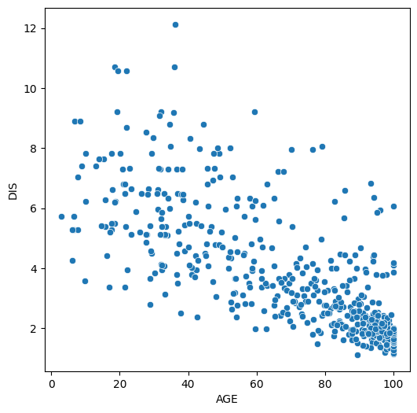

```python
# Scatterplot to visualize the relationship between AGE and DIS
plt.figure(figsize = (6, 6))

sns.scatterplot(x = 'AGE', y = 'DIS', data = df)

plt.show()
```

**Observations:**

The distance of the houses to the Boston employment centers appears to decrease moderately as the the proportion of the old houses increase in the town. It is possible that the Boston employment centers are located in the established towns where proportion of owner-occupied units built prior to 1940 is comparatively high.

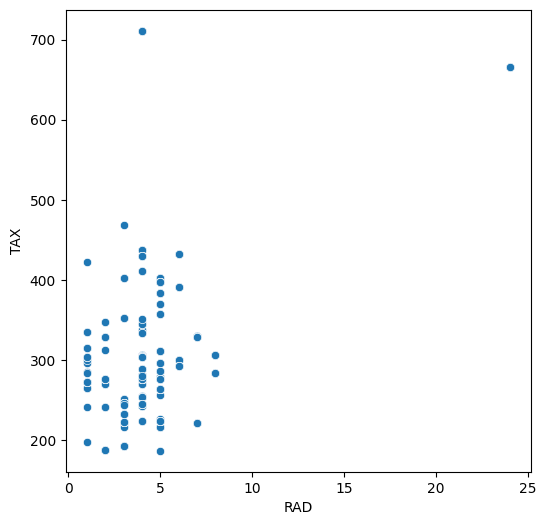

```python
# Scatterplot to visulaize the relationship between RAD and TAX
plt.figure(figsize = (6, 6))

sns.scatterplot(x = 'RAD', y = 'TAX', data = df)

plt.show()
```

**Observations:**

The correlation between RAD and TAX is very high. But, no trend is visible between the two variables. The strong correlation might be due to outliers. Let's check the correlation after removing the outliers.

```python
# Remove the data corresponding to high tax rate
df1 = df[df['TAX'] < 600]

# Import the required function
from scipy.stats import pearsonr

# Calculate the correlation
print('The correlation between TAX and RAD is', pearsonr(df1['TAX'], df1['RAD'])[0])
```

```
The correlation between TAX and RAD is 0.24975731331429196
```

**Observation:**

So, the high correlation between TAX and RAD is due to the outliers. The tax rate for some properties might be higher due to some other reason.

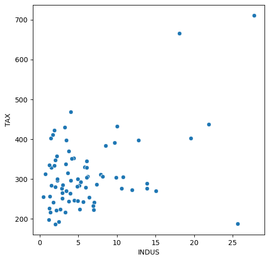

```python
# Scatterplot to visualize the relationship between INDUS and TAX
plt.figure(figsize = (6, 6))

sns.scatterplot(x = 'INDUS', y = 'TAX', data = df)

plt.show()
```

**Observation:**

The tax rate appears to increase with an increase in the proportion of non-retail business acres per town. This might be due to the reason that the variables TAX and INDUS are related with a third variable.

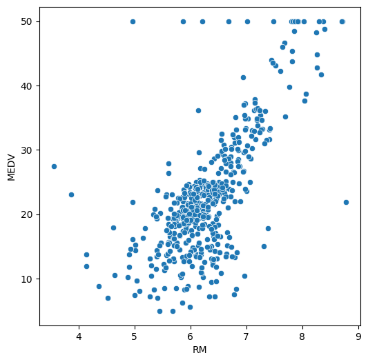

```python
# Scatterplot to visulaize the relationship between RM and MEDV
plt.figure(figsize = (6, 6))

sns.scatterplot(x = 'RM', y = 'MEDV', data = df)

plt.show()
```

**Observation:**

• The price of the house seems to increase as the value of RM increases. This is expected as the price is generally higher for more rooms.

• There are a few outliers in a horizontal line as the MEDV value seems to be capped at 50.

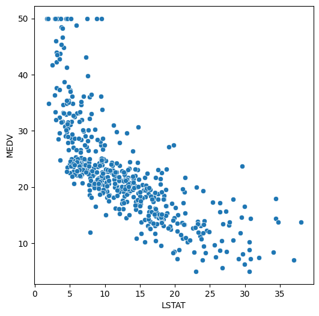

```python
# Scatterplot to visulaize the relationship between LSTAT and MEDV
plt.figure(figsize = (6, 6))

sns.scatterplot(x = 'LSTAT', y = 'MEDV', data = df)

plt.show()
```

**Observation:**

• The price of the house tends to decrease with an increase in LSTAT. This is also possible as the house price is lower in areas where people of lower status live

• There are few outliers and the data seems to be capped at 50

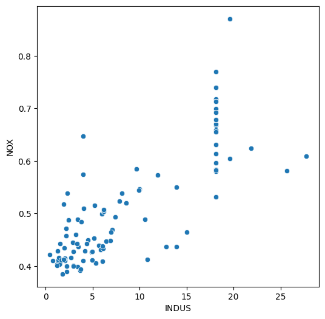

```python
# Scatterplot to visualize the relationship between INDUS and NOX
plt.figure(figsize = (6, 6))

sns.scatterplot(x = 'INDUS', y = 'NOX', data = df)

plt.show()
```

**Observation:**

• There is a clear positive relationship between INDUS and NOX — as the proportion of non-retail business (industrial) acreage increases, nitric oxide concentration rises alongside it

• The relationship is not perfectly linear; there appear to be two clusters — one group of towns with low INDUS (0–10%) and low NOX, and another with high INDUS (around 18%) and correspondingly high NOX, consistent with the bimodal distributions we noted earlier for both variables

• This makes intuitive sense — industrial activity is a primary source of air pollution, so towns with more industrial land use naturally exhibit higher pollution levels

• The correlation of 0.76 from the heatmap is clearly visible here as a strong upward trend

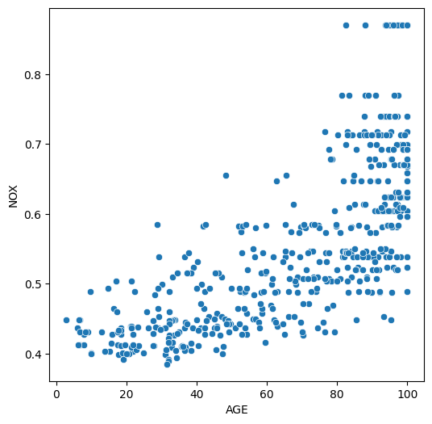

```python
# Scatterplot to visualize the relationship between AGE and NOX
plt.figure(figsize = (6, 6))

sns.scatterplot(x = 'AGE', y = 'NOX', data = df)

plt.show()
```

**Observation:**

• There is a **moderate positive relationship between AGE and NOX** — towns with a higher proportion of older homes (built before 1940) tend to have higher nitric oxide concentrations, consistent with the heatmap correlation of 0.73

• The relationship is more scattered compared to INDUS vs NOX, meaning AGE alone is not as clean a predictor of pollution as industrial activity is

• There are two visible bands in the plot — a lower NOX band (roughly 0.4–0.55) and an upper NOX band (roughly 0.6–0.87), again reflecting the bimodal nature of NOX noted earlier. Within each band, the upward trend with AGE is still visible

• The explanation is logical — **older, more established towns tend to have been industrialized for longer**, accumulating more pollution-generating infrastructure over time, whereas newer suburban developments farther from the city core tend to have both younger housing stock and cleaner air

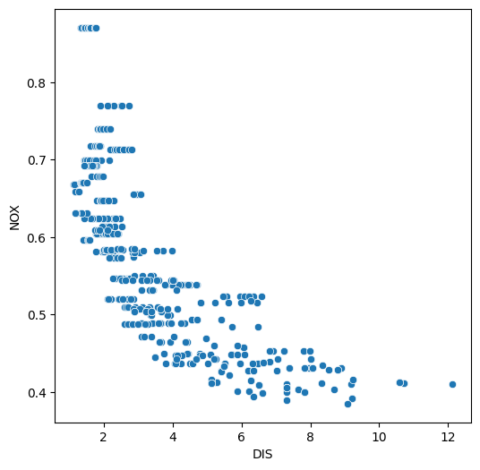

```python
# Scatterplot to visualize the relationship between DIS and NOX
plt.figure(figsize = (6, 6))

sns.scatterplot(x = 'DIS', y = 'NOX', data = df)

plt.show()
```

**Observation:**

• There is a clear negative relationship between DIS and NOX — as the weighted distance from Boston employment centers increases, nitric oxide concentration decreases

• The relationship appears non-linear — NOX drops steeply as distance increases from 1 to about 5, then flattens out at lower pollution levels beyond that point, suggesting a diminishing effect of distance on pollution reduction

• Most observations are clustered at shorter distances (DIS between 1 and 5), with fewer towns located far from employment centers, reflecting the urban density of the Boston metro area

• This is arguably the most meaningful of the three NOX scatterplots because distance to employment centers acts as a proxy for urbanization level, tying together the effects of industrial activity, housing age, and pollution into one variable.

**Split the dataset**

Let's split the data into the dependent and independent variables and further split it into train and test set in a ratio of 70:30 for train and test sets.

```python
# Separate the dependent variable and indepedent variables
Y = df['MEDV_log']

X = df.drop(columns = {'MEDV', 'MEDV_log'})

# Add the intercept term
X = sm.add_constant(X)
```

```python
# splitting the data in 70:30 ratio of train to test data
X_train, X_test, y_train, y_test = train_test_split(X, Y, test_size = 0.30, random_state = 1)
```

**Check for Multicollinearity**

We will use the Variance Inflation Factor (VIF), to check if there is multicollinearity in the data.

Features having a VIF score > 5 will be dropped / treated till all the features have a VIF score < 5

```python
from statsmodels.stats.outliers_influence import variance_inflation_factor

# Function to check VIF
def checking_vif(train):
    vif = pd.DataFrame()
    vif["feature"] = train.columns

    # Calculating VIF for each feature
    vif["VIF"] = [
        variance_inflation_factor(train.values, i) for i in range(len(train.columns))
    ]
    return vif


print(checking_vif(X_train))
```

```
    feature         VIF
0     const  535.372593
1      CRIM    1.924114
2        ZN    2.743574
3     INDUS    3.999538
4      CHAS    1.076564
5       NOX    4.396157
6        RM    1.860950
7       AGE    3.150170
8       DIS    4.355469
9       RAD    8.345247
10      TAX   10.191941
11  PTRATIO    1.943409
12    LSTAT    2.861881
```

**Observation:**

• There are two variables with high VIF - RAD and TAX (greater than 5)

• Let's remove TAX as it has the highest VIF values and check the multicollinearity again

```python
# Create the model after dropping TAX
X_train = X_train.drop(columns = ['TAX'])  ## Complete the code

# Check for VIF
print(checking_vif(X_train))
```

```
    feature         VIF
0     const  532.025529
1      CRIM    1.923159
2        ZN    2.483399
3     INDUS    3.270983
4      CHAS    1.050708
5       NOX    4.361847
6        RM    1.857918
7       AGE    3.149005
8       DIS    4.333734
9       RAD    2.942862
10  PTRATIO    1.909750
11    LSTAT    2.860251
```

Now, we will create the linear regression model as the VIF is less than 5 for all the independent variables, and we can assume that multicollinearity has been removed between the variables.

```python
# Create the model
model1 = sm.OLS(y_train, X_train).fit()  # Write your code here

# Get the model summary
model1.summary()
```

OLS Regression Results

| Dep. Variable: | MEDV_log | R-squared: | 0.769 |
| --- | --- | --- | --- |
| Model: | OLS | Adj. R-squared: | 0.761 |
| Method: | Least Squares | F-statistic: | 103.3 |
| Date: | Tue, 16 Jun 2026 | Prob (F-statistic): | 1.40e-101 |
| Time: | 01:24:01 | Log-Likelihood: | 76.596 |
| No. Observations: | 354 | AIC: | -129.2 |
| Df Residuals: | 342 | BIC: | -82.76 |
| Df Model: | 11 |  |  |
| Covariance Type: | nonrobust |  |  |

|  | coef | std err | t | P>\|t\| | [0.025 | 0.975] |
| --- | --- | --- | --- | --- | --- | --- |
| const | 4.6324 | 0.243 | 19.057 | 0.000 | 4.154 | 5.111 |
| CRIM | -0.0128 | 0.002 | -7.445 | 0.000 | -0.016 | -0.009 |
| ZN | 0.0010 | 0.001 | 1.425 | 0.155 | -0.000 | 0.002 |
| INDUS | -0.0004 | 0.003 | -0.148 | 0.883 | -0.006 | 0.005 |
| CHAS | 0.1196 | 0.039 | 3.082 | 0.002 | 0.043 | 0.196 |
| NOX | -1.0598 | 0.187 | -5.675 | 0.000 | -1.427 | -0.692 |
| RM | 0.0532 | 0.021 | 2.560 | 0.011 | 0.012 | 0.094 |
| AGE | 0.0003 | 0.001 | 0.461 | 0.645 | -0.001 | 0.002 |
| DIS | -0.0503 | 0.010 | -4.894 | 0.000 | -0.071 | -0.030 |
| RAD | 0.0076 | 0.002 | 3.699 | 0.000 | 0.004 | 0.012 |
| PTRATIO | -0.0452 | 0.007 | -6.659 | 0.000 | -0.059 | -0.032 |
| LSTAT | -0.0298 | 0.002 | -12.134 | 0.000 | -0.035 | -0.025 |

| Omnibus: | 30.699 | Durbin-Watson: | 1.923 |
| --- | --- | --- | --- |
| Prob(Omnibus): | 0.000 | Jarque-Bera (JB): | 83.718 |
| Skew: | 0.372 | Prob(JB): | 6.62e-19 |
| Kurtosis: | 5.263 | Cond. No. | 2.09e+03 |

Notes:  
[1] Standard Errors assume that the covariance matrix of the errors is correctly specified.  
[2] The condition number is large, 2.09e+03. This might indicate that there are  
strong multicollinearity or other numerical problems.

**Observation:**

**Overall Model Fit**

• R-squared = 0.769 and Adjusted R-squared = 0.761 — the model explains about 76-77% of the variation in log (MEDV), which is a reasonably strong fit

• The F-statistic p-value ≈ 1.4e-101 confirms the overall model is highly statistically significant

**Significant Predictors:**

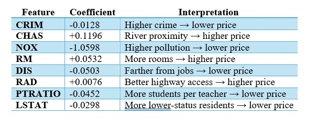

**Insignificant Predictors (p-value > 0.05)**

• **ZN (p = 0.155), INDUS (p = 0.883), and AGE (p = 0.645)** are not statistically significant at α = 0.05 — their coefficients are not meaningfully different from zero and they do not contribute to explaining house prices once other variables are accounted for

• These three variables will be dropped in the next iteration (model2) to produce a more parsimonious and reliable model.

**Examining the significance of the model**

It is not enough to fit a multiple regression model to the data, it is necessary to check whether all the regression coefficients are significant or not. Significance here means whether the population regression parameters are significantly different from zero.

From the above it may be noted that the regression coefficients corresponding to **ZN, AGE, and INDUS** **are not statistically significant at level α = 0.05.** In other words, the regression coefficients corresponding to these three are not significantly different from 0 in the population. Hence, we will eliminate the three features and create a new model.

```python
# Create the model after dropping columns 'MEDV', 'MEDV_log', 'TAX', 'ZN', 'AGE', 'INDUS' from df DataFrame
Y = df['MEDV_log']

X = df.drop(columns = ['MEDV', 'MEDV_log', 'TAX', 'ZN', 'AGE', 'INDUS'])  # Complete the code

X = sm.add_constant(X)

# Splitting the data in 70:30 ratio of train to test data
X_train, X_test, y_train, y_test = train_test_split(X, Y, test_size = 0.30, random_state = 1)

# Create the model
model2 = sm.OLS(y_train, X_train).fit()  ## Complete the code

# Get the model summary
model2.summary()
```

OLS Regression Results

| Dep. Variable: | MEDV_log | R-squared: | 0.767 |
| --- | --- | --- | --- |
| Model: | OLS | Adj. R-squared: | 0.762 |
| Method: | Least Squares | F-statistic: | 142.1 |
| Date: | Tue, 16 Jun 2026 | Prob (F-statistic): | 2.61e-104 |
| Time: | 01:24:01 | Log-Likelihood: | 75.486 |
| No. Observations: | 354 | AIC: | -133.0 |
| Df Residuals: | 345 | BIC: | -98.15 |
| Df Model: | 8 |  |  |
| Covariance Type: | nonrobust |  |  |

|  | coef | std err | t | P>\|t\| | [0.025 | 0.975] |
| --- | --- | --- | --- | --- | --- | --- |
| const | 4.6494 | 0.242 | 19.242 | 0.000 | 4.174 | 5.125 |
| CRIM | -0.0125 | 0.002 | -7.349 | 0.000 | -0.016 | -0.009 |
| CHAS | 0.1198 | 0.039 | 3.093 | 0.002 | 0.044 | 0.196 |
| NOX | -1.0562 | 0.168 | -6.296 | 0.000 | -1.386 | -0.726 |
| RM | 0.0589 | 0.020 | 2.928 | 0.004 | 0.019 | 0.098 |
| DIS | -0.0441 | 0.008 | -5.561 | 0.000 | -0.060 | -0.028 |
| RAD | 0.0078 | 0.002 | 3.890 | 0.000 | 0.004 | 0.012 |
| PTRATIO | -0.0485 | 0.006 | -7.832 | 0.000 | -0.061 | -0.036 |
| LSTAT | -0.0293 | 0.002 | -12.949 | 0.000 | -0.034 | -0.025 |

| Omnibus: | 32.514 | Durbin-Watson: | 1.925 |
| --- | --- | --- | --- |
| Prob(Omnibus): | 0.000 | Jarque-Bera (JB): | 87.354 |
| Skew: | 0.408 | Prob(JB): | 1.07e-19 |
| Kurtosis: | 5.293 | Cond. No. | 690. |

Notes:  
[1] Standard Errors assume that the covariance matrix of the errors is correctly specified.

**Model Summary:**

**Overall Model Fit:**

• R-squared = 0.767 and Adjusted R-squared = 0.762 — virtually identical to model1 (0.769 / 0.761), confirming that dropping ZN, INDUS, and AGE caused no meaningful loss of explanatory power while making the model simpler and more interpretable

• The Adjusted R-squared actually improved slightly from 0.761 to 0.762, which is expected — removing non-contributing variables reduces the penalty term in the adjusted R² formula

• F-statistic p-value ≈ 2.61e-104 — the overall model remains highly significant.

• LSTAT and NOX remain the strongest drivers of house price in terms of magnitude

• model2 is the final, clean model — all 8 predictors are statistically significant, multicollinearity has been addressed, and explanatory power is preserved. We can now proceed to check the regression assumptions

**Checking the below linear regression assumptions**

1. Mean of residuals should be 0
2. No Heteroscedasticity
3. Linearity of variables
4. Normality of error terms

**1. Check for mean residuals**

```python
residuals = model2.resid

np.mean(residuals)
```

```
np.float64(-2.5303049047106675e-15)
```

**Observation:**

• model2.resid extracts the residuals from the fitted model — these are the differences between the actual observed values of log(MEDV) and the values predicted by the model for each observation in the training set

• This satisfies the first linear regression assumption — the mean of residuals must equal zero, confirming that the model does not systematically over-predict or under-predict across the training data and that the regression line is correctly centered through the data

**2. Check for homoscedasticity**

Homoscedasticity - If the residuals are symmetrically distributed across the regression line, then the data is said to be homoscedastic.

Heteroscedasticity- - If the residuals are not symmetrically distributed across the regression line, then the data is said to be heteroscedastic. In this case, the residuals can form a funnel shape or any other non-symmetrical shape.

We'll use Goldfeldquandt Test to test the following hypothesis with alpha = 0.05:

Null hypothesis: Residuals are homoscedastic Alternate hypothesis: Residuals have heteroscedastic

```python
from statsmodels.stats.diagnostic import het_white

from statsmodels.compat import lzip

import statsmodels.stats.api as sms
```

```python
name = ["F statistic", "p-value"]

test = sms.het_goldfeldquandt(residuals, X_train)  ## Complete the code

lzip(name, test)
```

```
[('F statistic', np.float64(1.0835082923425288)),
 ('p-value', np.float64(0.30190120067668275))]
```

**Observation:**

• The Goldfeld-Quandt test checks the following hypothesis:

o Null Hypothesis (H₀): Residuals are homoscedastic (constant variance)

o Alternate Hypothesis (H₁): Residuals are heteroscedastic (non-constant variance)

• The test results are:

o F-statistic ≈ 1.084

o p-value ≈ 0.302

• Since the p-value (0.302) > α (0.05), we fail to reject the null hypothesis, concluding that the residuals are homoscedastic — the variance of the residuals is constant across all levels of the fitted values

• This satisfies the second linear regression assumption, meaning the model's errors are evenly spread and do not fan out or shrink as predicted values increase, which is important for ensuring that the standard errors of the coefficients are reliable and the model's predictions are equally trustworthy across the full range of house prices

**3. Linearity of variables**

1. It states that the predictor variables must have a linear relation with the dependent variable.
2. To test the assumption, we'll plot residuals and the fitted values on a plot and ensure that residuals do not form a strong pattern. They should be randomly and uniformly scattered on the x-axis.

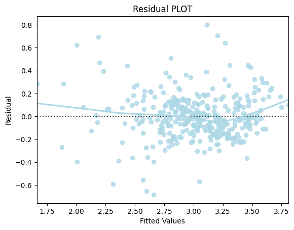

```python
# Predicted values
fitted = model2.fittedvalues

# sns.set_style("whitegrid")
sns.residplot(x = fitted, y = residuals, color = "lightblue", lowess = True)  ## Complete the code

plt.xlabel("Fitted Values")

plt.ylabel("Residual")

plt.title("Residual PLOT")

plt.show()
```

**Observation:**

• The residuals appear randomly and symmetrically scattered around the horizontal line at 0 across the full range of fitted values, with no obvious funnel shape, curve, or systematic pattern, an ideal outcome

• The lowess (locally weighted smoothing) line stays close to 0 throughout, with only minor deviations at the extreme ends of the fitted value range, suggesting the linearity assumption holds reasonably well across the middle of the distribution

• Overall, this plot satisfies the third linear regression assumption, that the predictor variables have a linear relationship with the dependent variable and confirms that a linear model is an appropriate choice for this data.

**4. Normality of error terms**

The residuals should be normally distributed.

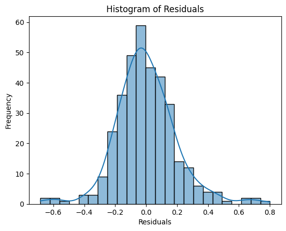

```python
# Plot histogram of residuals
sns.histplot(residuals, kde = True)
plt.title("Histogram of Residuals")
plt.xlabel("Residuals")
plt.ylabel("Frequency")
plt.show()
```

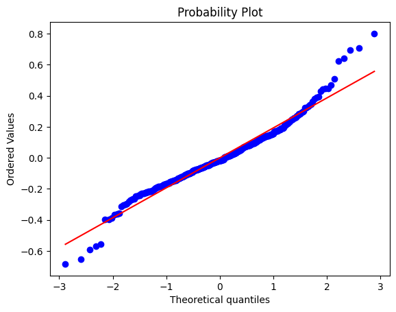

```python
# Plot q-q plot of residuals
import pylab

import scipy.stats as stats

stats.probplot(residuals, dist = "norm", plot = pylab)

plt.show()
```

**Observation:**

• The histogram shows a roughly bell-shaped, symmetric distribution centered around 0, which is the expected shape for normally distributed residuals

• The KDE (Kernel Density Estimate) curve overlaid on the histogram closely follows a normal distribution shape, further supporting normality of the residuals

• There is a slight right skew visible in the tail, meaning there are a few observations where the model significantly underpredicted the actual house price, these are likely the high-value homes where MEDV was capped at 50, introducing some distortion

• The bulk of residuals fall within a narrow range of approximately -0.4 to +0.4, indicating that most predictions are fairly close to the actual log(MEDV) values with no extreme systematic errors

**Check the performance of the model on the train and test data set**

```python
# RMSE
def rmse(predictions, targets):
    return np.sqrt(((targets - predictions) ** 2).mean())


# MAPE
def mape(predictions, targets):
    return np.mean(np.abs((targets - predictions)) / targets) * 100


# MAE
def mae(predictions, targets):
    return np.mean(np.abs((targets - predictions)))


# Model Performance on test and train data
def model_pref(olsmodel, x_train, x_test):

    # In-sample Prediction
    y_pred_train = olsmodel.predict(x_train)
    y_observed_train = y_train

    # Prediction on test data
    y_pred_test = olsmodel.predict(x_test)
    y_observed_test = y_test

    print(
        pd.DataFrame(
            {
                "Data": ["Train", "Test"],
                "RMSE": [
                    rmse(y_pred_train, y_observed_train),
                    rmse(y_pred_test, y_observed_test),
                ],
                "MAE": [
                    mae(y_pred_train, y_observed_train),
                    mae(y_pred_test, y_observed_test),
                ],
                "MAPE": [
                    mape(y_pred_train, y_observed_train),
                    mape(y_pred_test, y_observed_test),
                ],
            }
        )
    )


# Checking model performance
model_pref(model2, X_train, X_test)
```

```
    Data      RMSE       MAE      MAPE
0  Train  0.195504  0.143686  4.981813
1   Test  0.198045  0.151284  5.257965
```

**Observations on Model Performance:**

**• RMSE (Root Mean Squared Error)**

o Train (0.1955) and Test (0.1980) are extremely close, with only a 0.0025 difference, indicating the model is not overfitting to the training data

**• MAE (Mean Absolute Error)**

o Train (0.1437) and Test (0.1513) are again very close, meaning on average the model's predictions deviate by about 0.14–0.15 units on the log scale from the actual values. o MAE being lower than RMSE in both cases confirms there are no extreme outlier predictions dramatically inflating the error.

**• MAPE (Mean Absolute Percentage Error)**

o Train (4.98%) and (~5.26%) indicate the model predicts log(MEDV) within roughly 5% of the actual value on average, which is a strong result for a linear regression model. o The small gap of only 0.28% between train and test MAPE further confirms the model generalizes well to unseen data.

**• Overall Assessment**

o The near-identical metrics across train and test sets confirm the model is neither overfitting nor underfitting — it has found the right balance of complexity. o The consistency across all three metrics (RMSE, MAE, MAPE) tells the same story from three different angles, making this a robust and reliable model for predicting Boston house prices.

**Apply cross validation to improve the model and evaluate it using different evaluation metrics**

```python
# Import the required function

from sklearn.model_selection import cross_val_score

# Build the regression model and cross-validate
linearregression = LinearRegression()

cv_Score11 = cross_val_score(linearregression, X_train, y_train, cv = 10)
cv_Score12 = cross_val_score(linearregression, X_train, y_train, cv = 10,
                             scoring = 'neg_mean_squared_error')


print("RSquared: %0.3f (+/- %0.3f)" % (cv_Score11.mean(), cv_Score11.std() * 2))
print("Mean Squared Error: %0.3f (+/- %0.3f)" % (-1*cv_Score12.mean(), cv_Score12.std() * 2))
```

```
RSquared: 0.729 (+/- 0.232)
Mean Squared Error: 0.041 (+/- 0.023)
```

**Get model coefficients in a pandas DataFrame with column 'Feature' having all the features and column 'Coefs' with all the corresponding Coefs.**

```python
coef = model2.params

pd.DataFrame({'Feature' : coef.index, 'Coefs' : coef.values})
```

|  | Feature | Coefs |
| --- | --- | --- |
| 0 | const | 4.649386 |
| 1 | CRIM | -0.012500 |
| 2 | CHAS | 0.119773 |
| 3 | NOX | -1.056225 |
| 4 | RM | 0.058907 |
| 5 | DIS | -0.044069 |
| 6 | RAD | 0.007848 |
| 7 | PTRATIO | -0.048504 |
| 8 | LSTAT | -0.029277 |

**Conclusions:**

**Model Performance**

• The final linear regression model (model2) achieved an R-squared of 0.767, meaning it explains approximately 77% of the variation in Boston median house prices using just 8 predictors, with a test MAPE of ~5.26% confirming strong generalization to unseen data.

• All four linear regression assumptions were satisfied, zero mean residuals, homoscedasticity (GQ test p-value = 0.302), linearity, and approximate normality of errors, validating model2 as a statistically sound and reliable model.

**Key Findings from the Model**

• The most influential negative drivers of house price are LSTAT (% lower-status population, coefficient -0.029), NOX (pollution, coefficient -1.056), and PTRATIO (pupil-teacher ratio, coefficient -0.049).

• The most influential positive drivers are CHAS (Charles River proximity, +12% price premium) and RM (number of rooms, ~5.9% per additional room).

• Variables TAX, ZN, INDUS, and AGE were either multicollinear or statistically insignificant and were appropriately removed without loss of model explanatory power.

**Business Recommendations**

**1. Prioritize Pollution Reduction:**

NOX had the single largest coefficient magnitude (-1.056), meaning pollution has a dramatic negative impact on property values. Municipal authorities and urban planners should prioritize relocating industrial activity away from residential zones and enforcing stricter emissions controls, even modest reductions in NOX levels could translate to meaningful appreciation in surrounding property values.

**2. Invest in School Quality**

The PTRATIO coefficient (-0.049) confirms that every additional student per teacher is associated with a ~4.9% drop in median home value. School districts and local governments that invest in hiring more teachers and reducing class sizes are likely to see a direct positive return in the form of higher property values and a stronger local tax base.

**3. Target Low LSTAT Neighborhoods for Development**

LSTAT is the strongest overall predictor of house price (-0.029 per percentage point). Developers and investors should focus on neighborhoods showing early signs of gentrification, areas where LSTAT is beginning to decline, as these are likely to experience the sharpest price appreciation over time.

**4. Price River-Adjacent Properties at a Premium**

The CHAS coefficient (+0.120) translates to approximately a 12% price premium for properties bordering the Charles River, all else being equal. Real estate agents and appraisers should consistently factor in river proximity when valuing properties, and developers should actively seek waterfront or near-waterfront parcels.

**5. Room Count Remains a Reliable Value Driver**

With each additional room associated with a ~5.9% increase in price, home extensions and renovations that add rooms offer a quantifiable return on investment. This is a straightforward lever for homeowners and property developers looking to increase asset value.

**6. Be Cautious with Highway-Adjacent Properties**

While RAD (highway accessibility) has a small positive coefficient (+0.008), its strong correlation with TAX (0.91) and the high tax rates in those areas means the price benefit of highway access may be partially offset by higher property tax burdens — buyers and investors should evaluate the net financial impact rather than treating accessibility as an unambiguous positive.

**7. Model Limitation to Note**

MEDV was capped at $50,000 in the original dataset (in 1970 dollars), meaning the model may underestimate prices for the highest-value properties. Any application of this model to current real estate markets should be treated as directional guidance only, and the model should ideally be retrained on more recent, uncapped data before being used for actual pricing or investment decisions.